# RNAetc vignette

Functions helpful in RNAseq data analysis

Kim Dill-McFarland, kadm@uw.edu

version May 04, 2025

# Overview

This package is a collection of functions useful in RNAseq data analysis that don’t fit well into our other packages (see info-graphic). They are involved in data cleaning, data manipulation, WGCNA module analyses (mostly).

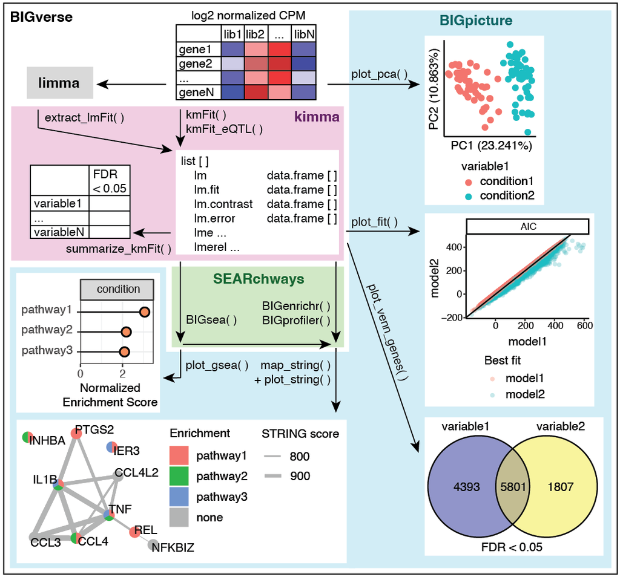

# Setup

## Software and packages

This pipeline should be completed in R version 4.5.0 (2025-04-11) or newer. Please also download the following packages.

```r
# CRAN packages
install.packages(c("tidyverse","patchwork"))

# Bioconductor packages
## These are dependencies for kimma that are beneficial to download separately
install.packages("BiocManager")
BiocManager::install(c("limma", "edgeR"))

# GitHub packages
install.packages("devtools")
devtools::install_github("BIGslu/kimma")
devtools::install_github("BIGslu/BIGpicture")
devtools::install_github("BIGslu/RNAetc")
devtools::install_github("BIGslu/SEARchways")
```

And load them into your current R session.

```r
library(tidyverse)
library(edgeR)
library(limma)
library(RNAetc)
library(kimma)
library(BIGpicture)
library(SEARchways)
library(patchwork)
```

To ensure reproducibility with this document, set the random seed value.

```r
set.seed(651)
```

## Data background

Example data were obtained from media controls and human rhinovirus (HRV) infected human plasmacytoid dendritic cells. You can learn more about these data in

> Dill-McFarland KA, Schwartz JT, Zhao H, Shao B, Fulkerson PC, Altman MC, Gill MA. 2022. Eosinophil-mediated suppression and Anti-IL-5 enhancement of plasmacytoid dendritic cell interferon responses in asthma. J Allergy Clin Immunol. Epub ahead of print. doi: 10.1016/j.jaci.2022.03.025. — [GitHub](https://github.com/altman-lab/P259_pDC_public)

Specifically, this vignette uses bulk human RNA-seq processed from fastq to counts using [SEAsnake](https://bigslu.github.io/SEAsnake/vignette/SEAsnake_vignette.html) and counts to voom using [edgeR/limma](https://bigslu.github.io/tutorials/RNAseq/2.Hawn_RNAseq_counts.to.voom.html). This results in voom-normalized, log2 counts per million (CPM) gene expression and associated sample and gene metadata. In total, 6 donors and 1000 random genes were selected for this vignette. Actual donor identifiers have been altered for privacy.

## Load data

Unnormalized RNAseq counts and metadata.

```r
example.dat <- RNAetc::example.dat
names(example.dat)
```

```
## [1] "counts"  "samples" "genes"
```

Voom normalized RNAseq counts and metadata.

```r
example.voom <- RNAetc::example.voom
names(example.voom)
```

```
## [1] "genes"   "targets" "E"       "weights" "design"
```

Example WGCNS modules.

```r
example.mods <- RNAetc::example.mods
head(example.mods)
```

```
##          geneName module module.char mod.color hgnc_symbol Previous symbols
## 1 ENSG00000005189      0          00      grey       REXO5             <NA>
## 2 ENSG00000006025      0          00      grey      OSBPL7             <NA>
## 3 ENSG00000006118      0          00      grey    TMEM132A         HSPA5BP1
## 4 ENSG00000007038      0          00      grey      PRSS21             <NA>
## 5 ENSG00000007080      0          00      grey     CCDC124             <NA>
## 6 ENSG00000008323      0          00      grey     PLEKHG6             <NA>
##      Alias symbols        gene_biotype
## 1           NEF-sp protein-coding gene
## 2   ORP7, MGC71150 protein-coding gene
## 3    GBP, FLJ20539 protein-coding gene
## 4     ESP-1, TEST1 protein-coding gene
## 5             <NA> protein-coding gene
## 6 FLJ10665, MYOGEF protein-coding gene
```

# RNAseq data cleaning

## `filter_rare`: Filter rare and low abundance genes

Remove genes that are not at least X counts per million (CPM) in at least Y samples or Z% of samples. Generally applied to a `DGEList` object prior to voom normalization.

```r
dim(example.dat)
```

```
## [1] 1000   12
```

```r
example.dat.filter <- filter_rare(dat = example.dat,
                                  min_CPM = 1,
                                  min_sample = 3,
                                  gene_var = "geneName")
```

```
## 46 (4.6%) of 1000 genes removed.
```

```r
dim(example.dat.filter)
```

```
## [1] 954  12
```

```r
example.dat.filter <- filter_rare(dat = example.dat,
                                  min_CPM = 1,
                                  min_pct = 10,
                                  gene_var = "geneName")
```

```
## 2 (0.2%) of 1000 genes removed.
```

```r
dim(example.dat.filter)
```

```
## [1] 998  12
```

Automatically plot the mean variance trends before and after filtering.

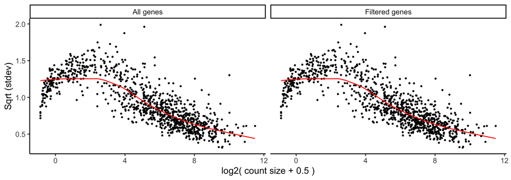

```
## 2 (0.2%) of 1000 genes removed.
```

```r
example.dat.filter <- filter_rare(dat = example.dat,
                                  min_CPM = 1,
                                  min_pct = 10,
                                  gene_var = "geneName",
                                  plot = TRUE)
```

Other parameters

- Use `gene_var` to identify the column in `dat$genes` to match to rownames in `dat$counts`

# RNAseq data manipulation

## Shared parameters

All of these functions can be tuned to different voom objects by setting the `libraryID` and `geneID` parameters to match column names in your data. The defaults of “libID” and “geneName”, respectively.

## `collapse_voom`: Combine voom object into a single dataframe

Collapse a voom object by matching the `libraryID` and `geneID` columns.

```r
names(example.voom)
```

```
## [1] "genes"   "targets" "E"       "weights" "design"
```

```r
dat2 <- collapse_voom(dat = example.voom)
colnames(dat2)
```

```
##  [1] "geneName"           "libID"              "value"
##  [4] "group"              "lib.size"           "norm.factors"
##  [7] "ptID"               "median_cv_coverage" "virus"
## [10] "asthma"             "batch"              "hgnc_symbol"
## [13] "Previous symbols"   "Alias symbols"      "gene_biotype"
```

```r
head(dat2)
```

```
## # A tibble: 6 × 15
##   geneName      libID value group lib.size norm.factors ptID  median_cv_coverage
##   <chr>         <chr> <dbl> <fct>    <dbl>        <dbl> <chr>              <dbl>
## 1 ENSG00000000… lib1   6.11 1       79646.        1.00  dono…              0.514
## 2 ENSG00000000… lib2   8.00 1       88008.        0.951 dono…              0.435
## 3 ENSG00000000… lib3   7.32 1      178020.        1.09  dono…              0.374
## 4 ENSG00000000… lib4   7.33 1      133836.        0.943 dono…              0.388
## 5 ENSG00000000… lib5   7.92 1      192547.        1.00  dono…              0.353
## 6 ENSG00000000… lib6   7.99 1      175144.        0.974 dono…              0.349
## # ℹ 7 more variables: virus <fct>, asthma <chr>, batch <dbl>,
## #   hgnc_symbol <chr>, `Previous symbols` <chr>, `Alias symbols` <chr>,
## #   gene_biotype <chr>
```

Add the gene-level weights in `dat$weights`

```r
dat2 <- collapse_voom(dat = example.voom,
                      include_weights = TRUE)
colnames(dat2)
```

```
##  [1] "geneName"           "libID"              "value"
##  [4] "group"              "lib.size"           "norm.factors"
##  [7] "ptID"               "median_cv_coverage" "virus"
## [10] "asthma"             "batch"              "hgnc_symbol"
## [13] "Previous symbols"   "Alias symbols"      "gene_biotype"
## [16] "weights"
```

## `subset_voom`: Subset voom object

Subset a voom object to specific libraries.

```r
dim(example.voom)
```

```
## [1] 1000   12
```

```r
dat.sub1 <- subset_voom(dat = example.voom,
                        lib_keep = c("lib1","lib3"))
```

```
## Subsetting to 2 of 12 libraries
```

```
## Subsetting to 1000 of 1000 genes
```

```
## Done!
```

```r
dim(dat.sub1)
```

```
## [1] 1000    2
```

Subset a voom object to remove specific libraries.

```r
dim(example.voom)
```

```
## [1] 1000   12
```

```r
dat.sub2 <- subset_voom(dat = example.voom,
                        lib_remove = c("lib1","lib3"))
```

```
## Subsetting to 10 of 12 libraries
```

```
## Subsetting to 1000 of 1000 genes
```

```
## Done!
```

```r
dim(dat.sub2)
```

```
## [1] 1000   10
```

Use the voom metadata to subset the object based on a logical statement. For example, keep all of the HRV infected samples. Be careful to use single quotations ’’ within the `lib_filter` parameter which is use double quotations “” overall.

```r
dim(example.voom)
```

```
## [1] 1000   12
```

```r
dat.sub3 <- subset_voom(dat = example.voom,
                        lib_filter = "virus == 'HRV'")
```

```
## Subsetting to 6 of 12 libraries
```

```
## Subsetting to 1000 of 1000 genes
```

```
## Done!
```

```r
dim(dat.sub3)
```

```
## [1] 1000    6
```

Instead of subsetting libraries, you can also subset to a vector of specific genes.

```r
dim(example.voom)
```

```
## [1] 1000   12
```

```r
dat.sub4 <- subset_voom(dat = example.voom,
                        gene_keep =c("ENSG00000000460","ENSG00000001460",
                                     "ENSG00000002587"))
```

```
## Subsetting to 12 of 12 libraries
```

```
## Subsetting to 3 of 1000 genes
```

```
## Done!
```

```r
dim(dat.sub4)
```

```
## [1]  3 12
```

## `combine_voom`: Combine 2 voom objects

Combine two voom objects.

```r
dim(dat.sub1)
```

```
## [1] 1000    2
```

```r
dim(dat.sub2)
```

```
## [1] 1000   10
```

```r
dat.recombine <- combine_voom(dat1 = dat.sub1, dat2 = dat.sub2)
```

```
## Combining genes: 1000 from dat1 and 1000 from dat2.
```

```
## Combining libraries: 2 from dat1 and 10 from dat2.
```

```
##
## Returning voom object with 12 libraries and 1000 genes.
```

```r
dim(dat.recombine)
```

```
## [1] 1000   12
```

# WGCNA modules

This group of functions works around gene co-expression modules created by [`WGCNA`](https://bmcbioinformatics.biomedcentral.com/articles/10.1186/1471-2105-9-559). `fit_modules`, `make_modules`, and `compare_modules` allow a subset of parameters from `WGCNA` that we commonly utilize. If you require further customization, we recommend running `WCGNA` functions directly.

## `fit_modules`: Perform soft thresholding

Used to determine the power to use for WGCNA module building.

```r
mod.fit <- fit_modules(dat = example.voom)
head(mod.fit$sft)
```

```
##   Power   SFT.R.sq     slope truncated.R.sq   mean.k. median.k.    max.k.
## 1     1 0.26313660  9.943599      0.8813112 502.00648 503.15088 531.43769
## 2     2 0.03041606 -1.797055      0.8636882 283.23033 280.65901 330.74298
## 3     3 0.02812478 -1.095957      0.8733717 173.48229 171.12225 226.52349
## 4     4 0.05936983 -1.048659      0.8945757 113.01295 111.05051 164.06308
## 5     5 0.11880939 -1.048333      0.9066056  77.24630  75.01133 123.94006
## 6     6 0.17295138 -1.048439      0.9210418  54.87881  52.62128  96.89712
##   signed.R.sq
## 1 -0.26313660
## 2  0.03041606
## 3  0.02812478
## 4  0.05936983
## 5  0.11880939
## 6  0.17295138
```

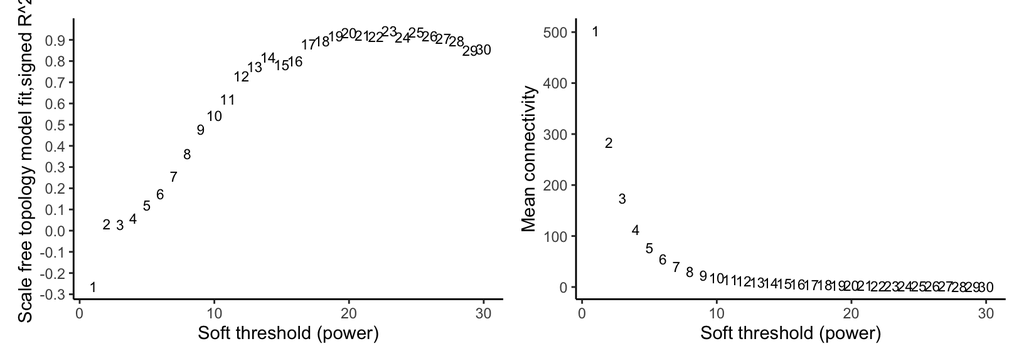

```r
mod.fit$top.plot + mod.fit$connect.plot
```

Change the power levels tested. For example, decrease to improve computational time or increase if you have not reached stability fo the default 30. In all honestly, though, 1:30 is generally sufficient and weirdness can happen at higher powers.

```r
mod.fit2 <- fit_modules(dat = example.voom,
                        powerVector = c(1:50))
```

```r
head(mod.fit2$sft)
```

```
##   Power   SFT.R.sq     slope truncated.R.sq   mean.k. median.k.    max.k.
## 1     1 0.26313660  9.943599      0.8813112 502.00648 503.15088 531.43769
## 2     2 0.03041606 -1.797055      0.8636882 283.23033 280.65901 330.74298
## 3     3 0.02812478 -1.095957      0.8733717 173.48229 171.12225 226.52349
## 4     4 0.05936983 -1.048659      0.8945757 113.01295 111.05051 164.06308
## 5     5 0.11880939 -1.048333      0.9066056  77.24630  75.01133 123.94006
## 6     6 0.17295138 -1.048439      0.9210418  54.87881  52.62128  96.89712
##   signed.R.sq
## 1 -0.26313660
## 2  0.03041606
## 3  0.02812478
## 4  0.05936983
## 5  0.11880939
## 6  0.17295138
```

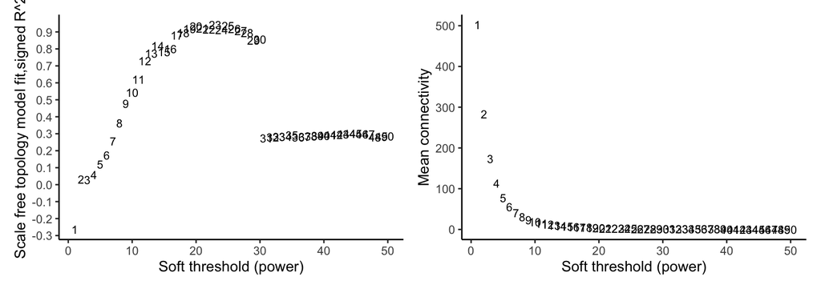

```r
mod.fit2$top.plot + mod.fit2$connect.plot
```

Use an “unsigned” or “signed hybrid” network instead of the default signed.

```r
mod.fit2 <- fit_modules(dat = example.voom,
                        networkType = "unsigned")
```

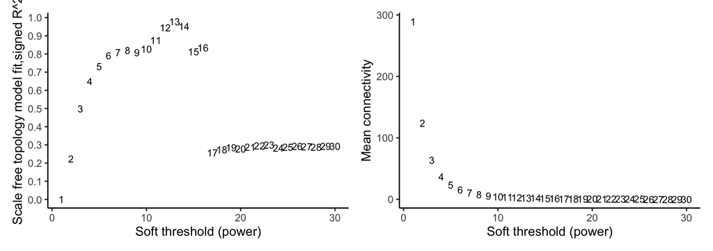

```r
mod.fit2$top.plot + mod.fit2$connect.plot
```

Use a subset of genes to create modules.

```r
mod.fit2 <- fit_modules(dat = example.voom,
                        genes = example.voom$genes$geneName[1:100])
```

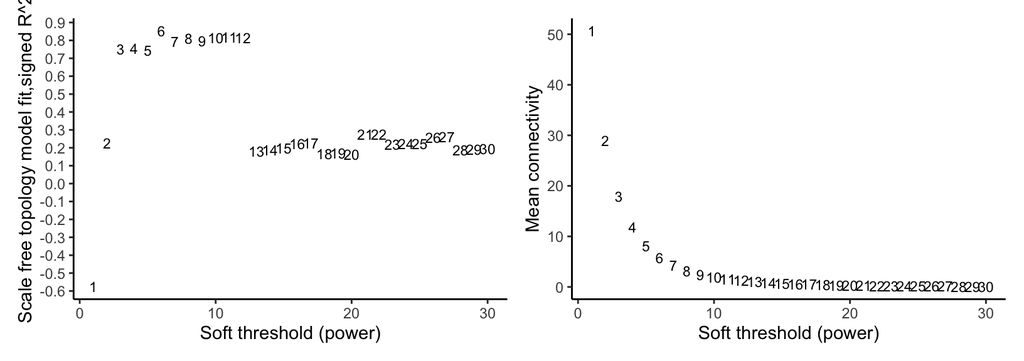

```r
mod.fit2$top.plot + mod.fit2$connect.plot
```

## `make_modules`: Construct WGCNA modules and associated data

Build modules using power based on `fit_modules` such as power that reaches an R-squared of 0.9.

```r
mods1 <- make_modules(fit = mod.fit,
                      Rsq_min = 0.9)
```

Or set it by-hand based on the thresholding plot local (which is what I’d do with these data) or absolute maximum.

```r
mods1 <- make_modules(fit = mod.fit,
                      sft_value = 14)
```

Provide additional results including `mods_mean` (mean gene expression by module), `mods_eigen` (eigenvalue expression by module), or `david` (DAVID formatted genes in modules data frame).

```r
mods1 <- make_modules(fit = mod.fit,
                      sft_value = 14,
                      mods_mean = TRUE,
                      mods_eigen = TRUE,
                      david = TRUE)
```

Other parameters

- Tune your module build with the following. See `WGCNA::blockwiseConsensusModules( )` for more details.
  - `minModuleSize`: Smallest possible module
  - `maxBlockSize`: Maximum number of genes to include in 1 dendrogram (many dendrograms go into making modules)
  - `deepSplit`: Build sensitivity, 0 least and 4 most sensitive
  - `networkType`, `TOMType`: Signed, unsigned, signed hybrid network creation

### A quick tour of module results

```r
names(mods1)
```

```
## [1] "genes"        "mods"         "sft"          "top.plot"     "connect.plot"
## [6] "mods.mean"    "mods.eigen"   "david"
```

- `mods1$genes`: Vector of genes used in module build
- `mods1$mods`: Module membership
- `mods1$sft`: Results from `fit_modules`
- `mods1$top.plot` and `mods1$connect.plot`: Plots from `fit_modules`
- `mods1$mods.mean`: Mean gene expression by module
- `mods1$mods.eigen`: Eigenvalue expression by module
- `mods1$david`: DAVID formatted genes in modules

## `compare_modules`: Compare WGCNA module builds

Used to help find the “best” module build. You can create many builds with varied R-squared, soft threshold, minimum module size, maximum block size, deep split, and/or network sign.

**Recommended**: Increase `nThread` to run on multiple processors and speed up results.

Compare 2 soft thresholds and 2 minimum sizes.

```r
comp1 <- compare_modules(fit = mod.fit,
                         sft_value = c(10,14),
                         minModuleSize = c(20,50),
                         nThread = 6)
```

```
## Running 4 module builds.
```

```r
names(comp1)
```

```
## [1] "summary" "modules"
```

```r
#View parameters
comp1$summary
```

```
##   sft_value  SFT.R.sq minModuleSize maxBlockSize deepSplit networkType TOMType
## 1        10 0.5419406            20          500         3      signed  signed
## 2        14 0.8185863            20          500         3      signed  signed
## 3        10 0.5419406            50          500         3      signed  signed
## 4        14 0.8185863            50          500         3      signed  signed
##    param genes mod0 modMin modMax modN
## 1 param1  1000   88     21    114   17
## 2 param2  1000   81     20     99   18
## 3 param3  1000  212     77    186    6
## 4 param4  1000  173     50    171    7
```

```r
#Summarize total genes in modules
plyr::ldply(comp1$modules) %>%
  pivot_wider(names_from = `.id`, values_from = n)
```

```
## # A tibble: 19 × 5
##    module param1 param2 param3 param4
##     <dbl>  <int>  <int>  <int>  <int>
##  1      0     88     81    212    173
##  2      1    114     99    186    171
##  3      2    104     91    174    171
##  4      3     77     81    140    140
##  5      4     71     75    107    105
##  6      5     64     75    104     99
##  7      6     61     68     77     91
##  8      7     61     68     NA     50
##  9      8     53     50     NA     NA
## 10      9     48     45     NA     NA
## 11     10     46     38     NA     NA
## 12     11     39     37     NA     NA
## 13     12     36     36     NA     NA
## 14     13     33     35     NA     NA
## 15     14     32     32     NA     NA
## 16     15     28     24     NA     NA
## 17     16     24     23     NA     NA
## 18     17     21     22     NA     NA
## 19     18     NA     20     NA     NA
```

Compare 2 R-squared and 2 deep splits. Or many other combinations…

```r
comp2 <- compare_modules(fit = mod.fit,
                         Rsq_min = c(0.8,0.9),
                         deepSplit = c(1,4))
```

```
Running 4 module builds.
```

Other parameters

- Tune your module builds with the following. In this version, each can be a vector of multiple values to test and compare results. See `WGCNA::blockwiseConsensusModules( )` for more details.
  - `minModuleSize`: Smallest possible module
  - `maxBlockSize`: Maximum number of genes to include in 1 dendrogram (many dendrograms go into making modules)
  - `deepSplit`: Build sensitivity, 0 least and 4 most sensitive
  - `networkType`, `TOMType`: Signed, unsigned, signed hybrid network creation

## `calculate_module_coherence`: Calculate WGCNA module coherence

Calculate expression correlation between genes within modules. Compare coherence for modules built within the same data set (example below) or from another data set.

```r
coher <- calculate_module_coherence(
  mods = mods1$mods, mods_title = "Study1",
  dat = example.voom, dat_title = "Study1")
```

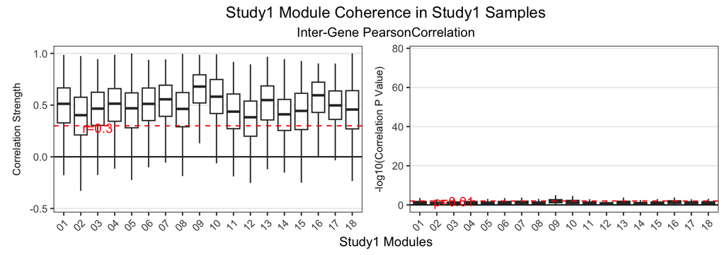

```r
#correlation data
head(coher$subgene_correlation_df)
```

```
##   Set           gene1           gene2       Cor           P
## 1  01 ENSG00000000460 ENSG00000006712 0.7910182 0.002183823
## 2  01 ENSG00000000460 ENSG00000022556 0.4780634 0.115948989
## 3  01 ENSG00000000460 ENSG00000025156 0.4154863 0.179201540
## 4  01 ENSG00000000460 ENSG00000033627 0.7003896 0.011192596
## 5  01 ENSG00000000460 ENSG00000037749 0.5549353 0.061095997
## 6  01 ENSG00000000460 ENSG00000064703 0.6346082 0.026642565
```

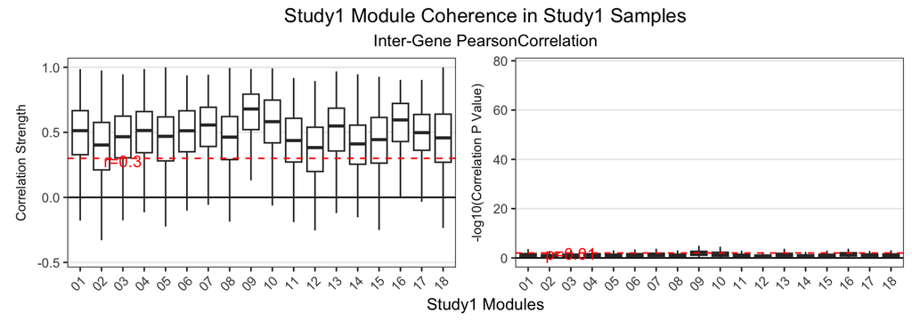

```r
#Correlations and significance
coher$coherence_boxplot_combined
```

Change the red cutoff lines in the plots.

```r
coher <- calculate_module_coherence(
  mods = mods1$mods, mods_title = "Study1",
  dat = example.voom, dat_title = "Study21",
  r_cutoff = 0.5,
  p_cutoff = 0.05)
```

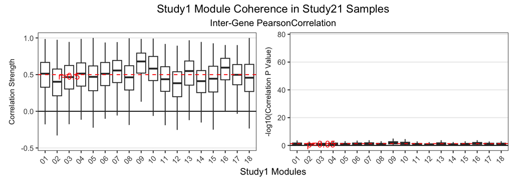

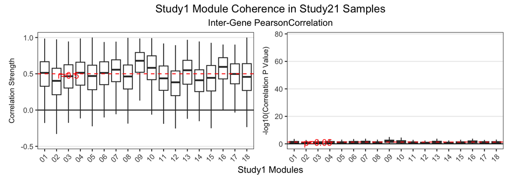

```r
coher$coherence_boxplot_combined
```

Other parameters

- Use `mods_var` and `gene_var` to change the columns used to define modules and genes
- `remove_mods` allows you to ignore select modules. By default, it removes the 0 or grey uncorrelated module.
- Don’t make the plots with `return_plot = FALSE`